# Practical Machine Learning Project

Yiyang Hu

4/8/2017

## Background

Using devices such as Jawbone Up, Nike FuelBand, and Fitbit it is now possible to collect a large amount of data about personal activity relatively inexpensively. These type of devices are part of the quantified self movement – a group of enthusiasts who take measurements about themselves regularly to improve their health, to find patterns in their behavior, or because they are tech geeks. One thing that people regularly do is quantify how much of a particular activity they do, but they rarely quantify how well they do it.

In this project, we will be to use data from accelerometers on the belt, forearm, arm, and dumbell of 6 participants. They were asked to perform barbell lifts correctly and incorrectly in 5 different ways. More information is available from the website here: http://groupware.les.inf.puc-rio.br/har (see the section on the Weight Lifting Exercise Dataset).

## Data Sources

The training data for this project are available here:

https://d396qusza40orc.cloudfront.net/predmachlearn/pml-training.csv

The test data are available here:

https://d396qusza40orc.cloudfront.net/predmachlearn/pml-testing.csv

## Goals

The goal of this project is to predict the manner in which they did the exercise. This is the “classe” variable in the training set. We may use any of the other variables to predict with. We will create a report describing how we built the model, how we used cross validation, what we think the expected out of sample error is, and why we made the choices. We will also use your prediction model to predict 20 different test cases.

## Data Processing

### Load Data

We load the R packages and wonload training & testing data sets from the above URLs.

```r
library(caret);
```

```r
library(rpart);
library(rpart.plot);
library(rattle);
library(randomForest);
library(RColorBrewer);

set.seed(12345);
trainingURL <- "https://d396qusza40orc.cloudfront.net/predmachlearn/pml-training.csv";
testingURL  <- "https://d396qusza40orc.cloudfront.net/predmachlearn/pml-testing.csv";

training <- read.csv(url(trainingURL),na.strings= c("NA","#DIV/0!",""))
testing <- read.csv(url(testingURL),na.strings= c("NA","#DIV/0!",""))
```

### Partition Data

We now will partition training data set into two different sets, 60% as training data and the remaining 40% as testing data.

```r
inTrain <- createDataPartition(training$classe, p= 0.6, list= FALSE)
trainingData <- training[inTrain,]
testingData <-training[-inTrain,]
dim(trainingData)
```

```
## [1] 11776   160
```

```r
dim(testingData)
```

```
## [1] 7846  160
```

### Clean Data

We then remove the NearZeroVariance variables

```r
nzv <- nearZeroVar(trainingData, saveMetrics = TRUE)
trainingData <- trainingData[,nzv$nzv == FALSE]

nzv <- nearZeroVar(testingData, saveMetrics =  TRUE)
testingData <- testingData[,nzv$nzv == FALSE]
```

Next we remove the 1st column of data set (ID) so that the ID variable won’t interfere with Machine Learning Algorithms.

```r
trainingData <- trainingData[c(-1)]
```

After that, we can clean up and remove the variable that has more than 60% of NA’s.

```r
trainingDataTemp <- trainingData

for (i in 1:length(trainingData)) {
        if (sum (is.na(trainingData[,i]))/nrow(trainingData) >=0.6) {
                for (j in 1: length(trainingDataTemp)) {
                        if (length(grep(names(trainingData[i]),names(trainingDataTemp)[j])) ==1){
                                trainingDataTemp <- trainingDataTemp[, -j]
                        }
                }
        }
}

trainingData <- trainingDataTemp
rm(trainingDataTemp)
dim(trainingData)
```

```
## [1] 11776    58
```

We will apply the same procedures for testing data: first themove the classe column, then make sure the variables in training data testing data are consistent

```r
column <- colnames(trainingData)
column2 <- colnames(trainingData[,-58])
testingData <- testingData[column]
testing <- testing[column2]

dim(testingData)
```

```
## [1] 7846   58
```

```r
dim(testing)
```

```
## [1] 20 57
```

```r
testingDataTemp <- testingData

for (i in 1:length(testingData)) {
        if (sum (is.na(testingData[,i]))/nrow(testingData) >=0.6) {
                for (j in 1: length(testingDataTemp)) {
                        if (length(grep(names(testingData[i]),names(testingDataTemp)[j])) ==1){
                                testingDataTemp <- testingDataTemp[, -j]
                        }
                }
        }
}

testingData <- testingDataTemp
rm(testingDataTemp)

# Removing row 2 as it doesn't have much use
testing <- rbind(trainingData[2,-58],testing)
testing <- testing[-1,]
```

## Prediction Algorithms

### Decision tree

Here we are choosing k = 5 for k-fold cross validation.

```r
set.seed(12345)
control <- trainControl(method="cv", number = 5)
fit_rpart <- train(classe ~., data= trainingData, method="rpart", trControl = control)
print(fit_rpart, digits= 4)
```

```
## CART
##
## 11776 samples
##    57 predictor
##     5 classes: 'A', 'B', 'C', 'D', 'E'
##
## No pre-processing
## Resampling: Cross-Validated (5 fold)
## Summary of sample sizes: 9422, 9421, 9420, 9421, 9420
## Resampling results across tuning parameters:
##
##   cp       Accuracy  Kappa
##   0.04485  0.4911    0.34034
##   0.04623  0.4522    0.26845
##   0.11450  0.3482    0.09736
##
## Accuracy was used to select the optimal model using  the largest value.
## The final value used for the model was cp = 0.04485.
```

[figure not shown]

```r
fancyRpartPlot(fit_rpart$finalModel)
```

```r
# Using validation set to predict outcomes
predict_rpart <- predict(fit_rpart, testingData)
# Prediction result
(conf_rpart <- confusionMatrix(testingData$classe,predict_rpart))
```

```
## Confusion Matrix and Statistics
##
##           Reference
## Prediction    A    B    C    D    E
##          A 1863    0  361    0    8
##          B  787    0  731    0    0
##          C  253    0 1115    0    0
##          D  491    0  795    0    0
##          E  121    0  661    0  660
##
## Overall Statistics
##
##                Accuracy : 0.4637
##                  95% CI : (0.4526, 0.4748)
##     No Information Rate : 0.4669
##     P-Value [Acc > NIR] : 0.718
##
##                   Kappa : 0.3084
##  Mcnemar's Test P-Value : NA
##
## Statistics by Class:
##
##                      Class: A Class: B Class: C Class: D Class: E
## Sensitivity            0.5300       NA   0.3044       NA  0.98802
## Specificity            0.9148   0.8065   0.9395   0.8361  0.89106
## Pos Pred Value         0.8347       NA   0.8151       NA  0.45770
## Neg Pred Value         0.7057       NA   0.6067       NA  0.99875
## Prevalence             0.4480   0.0000   0.4669   0.0000  0.08514
## Detection Rate         0.2374   0.0000   0.1421   0.0000  0.08412
## Detection Prevalence   0.2845   0.1935   0.1744   0.1639  0.18379
## Balanced Accuracy      0.7224       NA   0.6220       NA  0.93954
```

```r
# Accuracy rate of this prediction
(accuracy_rpart <- conf_rpart$overall[1])
```

```
##  Accuracy
## 0.4636758
```

With only about 46% accuracy rate, classifiction tree doesn’t do a good job predicting the outcome so we should move on to the next method.

### Random forest

```r
set.seed(12345)
mod_rf <- randomForest(classe ~., data= trainingData)

# In-sample error
pred_rf <- predict(mod_rf, testingData, type= "class")

# Confusion Matrix checking for test results
cm_rf <- confusionMatrix(pred_rf, testingData$classe)
cm_rf
```

```
## Confusion Matrix and Statistics
##
##           Reference
## Prediction    A    B    C    D    E
##          A 2231    2    0    0    0
##          B    1 1516    0    0    0
##          C    0    0 1367    3    0
##          D    0    0    1 1282    1
##          E    0    0    0    1 1441
##
## Overall Statistics
##
##                Accuracy : 0.9989
##                  95% CI : (0.9978, 0.9995)
##     No Information Rate : 0.2845
##     P-Value [Acc > NIR] : < 2.2e-16
##
##                   Kappa : 0.9985
##  Mcnemar's Test P-Value : NA
##
## Statistics by Class:
##
##                      Class: A Class: B Class: C Class: D Class: E
## Sensitivity            0.9996   0.9987   0.9993   0.9969   0.9993
## Specificity            0.9996   0.9998   0.9995   0.9997   0.9998
## Pos Pred Value         0.9991   0.9993   0.9978   0.9984   0.9993
## Neg Pred Value         0.9998   0.9997   0.9998   0.9994   0.9998
## Prevalence             0.2845   0.1935   0.1744   0.1639   0.1838
## Detection Rate         0.2843   0.1932   0.1742   0.1634   0.1837
## Detection Prevalence   0.2846   0.1933   0.1746   0.1637   0.1838
## Balanced Accuracy      0.9996   0.9993   0.9994   0.9983   0.9996
```

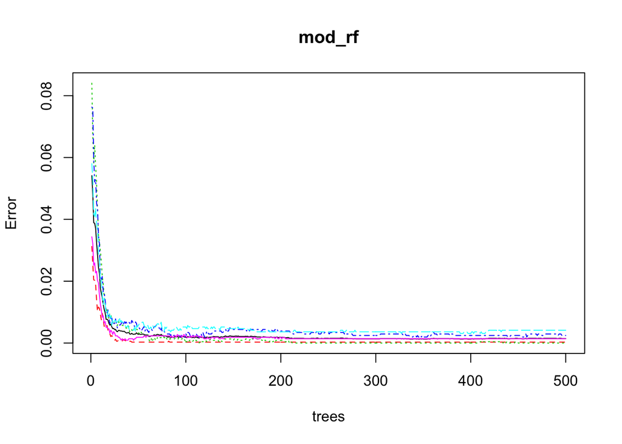

```r
 plot(mod_rf)
```

We could see that random forest gives us a 99% accuracy rate, which is noticeably better than the earlier decision tree method.

## Predict the testing set

```r
predict_test <- predict(mod_rf,testing, type="class")
predict_test
```

[output not shown]

So now with the random forest method, we are able to predict the testing set “classe” variable as above.